# Benchmark Comparison of Causal Inference Methods for High-Dimensional Data

cfomics Benchmark Suite

cfomics Development Team

2026-01-31

# 1 はじめに

## 1.1 背景

観測データからの因果推論は、生物医学研究、疫学、社会科学における基本的な課題である。倫理的、実務的、または経済的な制約によりランダム化比較試験が実施不可能な場合、研究者は処置効果を推定するために観測研究に頼らざるを得ない。しかしながら、観測データは重大な課題を呈する：交絡バイアス、選択バイアス、モデルの誤指定はすべて誤った結論につながる可能性がある。

生物学におけるハイスループット技術の出現—ゲノミクス、トランスクリプトミクス、プロテオミクス、メタボロミクスを含む—は、さらなる複雑さの層を生み出している。現代の生物医学データセットには、通常利用可能なサンプルサイズをはるかに超える数百から数千の潜在的交絡因子が日常的に含まれている。この高次元設定（$p \gg n$ または $p \approx n$）は、古典的な因果推論手法の前提条件を侵害するため、専門的なアプローチが必要となる。

## 1.2 高次元データの課題

逆確率重み付け（IPW）やアウトカム回帰などの古典的因果推論手法は、高次元設定においていくつかの困難に直面する：

1. **次元の呪い**：共変量の数がサンプルサイズに近づくか超える場合、傾向スコアモデルが不安定になる。
2. **変数選択**：どの共変量を含めるかの決定は重要である；非交絡因子を含めると効率が低下し、真の交絡因子を除外するとバイアスが生じる。
3. **モデルの誤指定**：線形モデルは共変量、処置、およびアウトカム間の複雑な関係を十分に捉えられない可能性がある。
4. **弱いオーバーラップ**：次元が増加すると、処置群と対照群の共変量オーバーラップが最小限になり、極端な傾向スコア重みにつながる。

## 1.3 ベンチマーク研究の目的

本ベンチマーク研究は、高次元データ向けに設計された因果推論手法を体系的に評価する。その目的は以下の通りである：

## 1.4 評価対象手法

高次元因果推論に対する異なるアプローチを代表する5つの手法を評価する：

| 手法 | アプローチ | 主な特徴 |
| --- | --- | --- |
| G-formula | アウトカム回帰 | 直接的なアウトカムモデリング |
| HDML | 機械学習 | 脱バイアス/二重機械学習 |
| HDPS | 傾向スコアベース | 高次元傾向スコア法 |
| BCF | ベイズ | ベイズ因果フォレスト |
| TMLE | セミパラメトリック | 標的最尤推定 |

各手法は異なる仮定、推定戦略、および計算要件を具現化している。包括的なシナリオセットにわたって評価することで、それぞれの相対的な強みと限界を特定することを目指す。

## 1.5 レポートの構成

# 2 手法

本章では、このベンチマークで評価される5つの因果推論手法について説明する。各手法について、理論的基礎、重要な仮定、およびcfomicsパッケージでの実装詳細を概説する。

## 2.1 記法と設定

$i = 1, \ldots, n$ について観測データ $(Y_i, T_i, X_i)$ を考える。ここで：

- $Y_i \in \mathbb{R}$ は観測されたアウトカム
- $T_i \in \{0, 1\}$ は二値の処置指標
- $X_i \in \mathbb{R}^p$ は $p$ 次元の共変量ベクトル

潜在アウトカムの枠組みの下で、$Y_i(1)$ と $Y_i(0)$ をそれぞれ処置下と対照下の潜在アウトカムとする。観測されたアウトカムは $Y_i = T_i Y_i(1) + (1-T_i) Y_i(0)$ である。

**平均処置効果（ATE）** は以下のように定義される：
$$\tau = \mathbb{E}[Y(1) - Y(0)]$$

個体 $i$ の**個体処置効果（ITE）** は：
$$\tau_i = Y_i(1) - Y_i(0)$$

標準的な因果仮定の下で作業を行う：

1. **SUTVA**：$Y_i = Y_i(T_i)$（個体間の干渉なし）
2. **一貫性**：観測されたアウトカムは受けた処置に対応する潜在アウトカムと等しい
3. **無交絡性**：$\{Y(0), Y(1)\} \perp\!\!\!\perp T \mid X$
4. **オーバーラップ（陽性）**：すべての $X$ について $0 < P(T=1 \mid X) < 1$

## 2.2 G-formula（アウトカム回帰）

### 2.2.1 理論的基礎

G-formula は標準化またはアウトカム回帰としても知られ、条件付きアウトカム平均をモデル化し共変量分布上で積分することでATEを推定する：

$$\hat{\tau}_{GF} =
\frac{1}{n}\sum_{i=1}^n \left[\hat{\mu}_1(X_i) -
\hat{\mu}_0(X_i)\right]$$

ここで $\hat{\mu}_t(x) = \mathbb{E}[Y \mid T=t, X=x]$ は推定された条件付き平均である。

### 2.2.2 高次元への適応

高次元では、標準的な回帰は失敗する。我々の実装では、$\mu_t(x)$ の推定に正則化回帰（Elastic Net）を使用する：

$$\hat{\mu}_t = \arg\min_\mu
\sum_{i:T_i=t} (Y_i - \mu(X_i))^2 + \lambda \left(\alpha \|\mu\|_1 +
(1-\alpha)\|\mu\|_2^2\right)$$

### 2.2.3 主要な特性

- **強み**：シンプル、解釈可能、アウトカムモデルが正しく指定されている場合に効率的
- **限界**：アウトカムモデルの誤指定に敏感；交絡因子に対する原理的な変数選択がない

### 2.2.4 実装

```r
cf_fit(formula, data, method = "gformula")
```

$\lambda$ の選択に交差検証を用いた `glmnet` を使用する。

## 2.3 HDML（高次元機械学習 / Double ML）

### 2.3.1 理論的基礎

HDML は Chernozhukov et al. (2018) の二重/脱バイアス機械学習フレームワークを実装する。重要な洞察は、柔軟な機械学習手法を使用しながら過適合バイアスを回避するためにクロスフィッティングを使用することである。

推定量はモーメント条件を解く：
$$\mathbb{E}\left[\psi(Y, T, X; \tau,
\eta_0)\right] = 0$$

ここで $\psi$ は二重頑健影響関数である：
$$\psi =
\left(\frac{T}{\pi(X)} - \frac{1-T}{1-\pi(X)}\right)(Y - \mu_T(X)) +
\mu_1(X) - \mu_0(X) - \tau$$

そして $\eta_0 = (\mu_0, \mu_1, \pi)$ はクロスフィッティングにより推定されるニューサンスパラメータである。

### 2.3.2 クロスフィッティング手順

1. データを $K$ 個のフォールドに分割
2. 各フォールド $k$ について：
   - フォールド $k$ 以外のすべてのデータでニューサンスモデル $(\hat{\mu}_0^{-k}, \hat{\mu}_1^{-k}, \hat{\pi}^{-k})$ を学習
   - フォールド $k$ で予測
3. すべての予測を使用してモーメント条件を解く

### 2.3.3 主要な特性

- **強み**：二重頑健（アウトカムまたは傾向モデルのいずれかが正しければ一致）；収束率に寛容（ニューサンスパラメータはより遅い収束率でも可）
- **限界**：ML手法の慎重なチューニングが必要；計算集約的

### 2.3.4 実装

```r
cf_fit(formula, data, method = "hdml")
```

ニューサンス推定にランダムフォレスト、勾配ブースティング、Elastic Netのアンサンブルを使用する。

## 2.4 HDPS（高次元傾向スコア）

### 2.4.1 理論的基礎

Schneeweiss et al. (2009) の高次元傾向スコア（HDPS）手法は、データ駆動の共変量優先順位付けにより傾向スコア手法を高次元設定に適応させる。

ATEは逆確率重み付けにより推定される：
$$\hat{\tau}_{HDPS} = \frac{1}{n}\sum_{i=1}^n
\frac{T_i Y_i}{\hat{\pi}(X_i)} - \frac{1}{n}\sum_{i=1}^n \frac{(1-T_i)
Y_i}{1-\hat{\pi}(X_i)}$$

ここで $\hat{\pi}(x)$ は選択された共変量サブセットを使用して推定された傾向スコアである。

### 2.4.2 共変量優先順位付けアルゴリズム

1. **再コード化**：連続共変量から二値指標を作成
2. **有病率フィルタリング**：被験者の5%未満に現れる共変量を削除
3. **バイアスランキング**：交絡の可能性によって共変量をランク付け（Brossバイアス公式）
4. **選択**：傾向モデル用に上位 $k$ 個の共変量を選択

### 2.4.3 主要な特性

- **強み**：解釈可能な選択プロセス；多くの二値指標（例：医療保険請求データ）で良好
- **限界**：傾向モデルのみに依存；オーバーラップ違反に敏感；二値共変量向けに設計

### 2.4.4 実装

```r
cf_fit(formula, data, method = "hdps")
```

設定可能な選択パラメータを備えた完全なHDPSアルゴリズムを実装する。

## 2.5 BCF（ベイズ因果フォレスト）

### 2.5.1 理論的基礎

ベイズ因果フォレスト（Hahn et al., 2020）は、予後関数と処置効果関数を分離することでBART（ベイズ加法回帰木）を因果推論に拡張する：

$$Y_i = f(X_i) + \tau(X_i) T_i +
\epsilon_i$$

ここで： - $f(X_i)$ は予後効果（ベースラインリスク）を捉える - $\tau(X_i)$ は異質的処置効果を捉える

$f$ と $\tau$ の両方がBARTの事前分布を使用してモデル化されるが、異なる正則化を持つ：

- $f$ は複雑なベースライン関係を捉えるために標準的なBART事前分布を使用
- $\tau$ は均質な効果に向けて収縮するより正則化された事前分布を使用

### 2.5.2 傾向スコアの統合

BCFは推定された傾向スコア $\hat{\pi}(X_i)$ を $f$ の共変量として組み込み、これにより： - 交絡に対する標的化された正則化を提供 - RIC（正則化誘発交絡）下での性能を向上

### 2.5.3 主要な特性

- **強み**：優れた不確実性定量化；異質性を自然に扱う；モデル誤指定に対して頑健
- **限界**：計算コストが高い；MCMCの収束を監視する必要がある

### 2.5.4 実装

```r
cf_fit(formula, data, method = "bcf")
```

MCMCサンプリングを備えた `bcf` Rパッケージを使用する。デフォルト：バーンイン1000回、事後サンプル2000回。

## 2.6 TMLE（標的最尤推定）

### 2.6.1 理論的基礎

TMLE（van der Laan & Rose, 2011）は、初期のアウトカム回帰と標的化ステップを組み合わせて最適なバイアス・分散トレードオフを保証するセミパラメトリック効率的推定量である。

### 2.6.2 アルゴリズム

1. **初期推定**：アウトカムモデル $\hat{\mu}_0^{(0)}(X)$ と傾向モデル $\hat{\pi}(X)$ を適合
2. **標的化**：以下を適合して $\hat{\mu}$ を更新：
   $$\text{logit}(\hat{\mu}^{(1)}) =
   \text{logit}(\hat{\mu}^{(0)}) + \epsilon \cdot H$$
   ここで $H = T/\hat{\pi}(X) - (1-T)/(1-\hat{\pi}(X))$ はclever covariate
3. **代入**：標的化された予測を使用してATEを計算：
   $$\hat{\tau}_{TMLE} = \frac{1}{n}\sum_i
   \hat{\mu}_1^{(1)}(X_i) - \hat{\mu}_0^{(1)}(X_i)$$

### 2.6.3 主要な特性

- **強み**：二重頑健；セミパラメトリック効率的；パラメータ境界を尊重；妥当な推論
- **限界**：慎重な実装が必要；極端な傾向スコアに敏感な場合がある

### 2.6.4 Super Learnerとの統合

我々の実装では、初期推定にSuper Learner（ML手法のアンサンブル）を使用する：

```r
cf_fit(formula, data, method = "tmle")
```

交差検証されたSuper Learnerライブラリを備えた `tmle` Rパッケージを使用する。

## 2.7 手法比較の要約

手法特性の要約

[output not shown]

*注：BCFは傾向スコアを組み込むが、古典的な意味で二重頑健ではない。*

# 3 シミュレーション設計

## 3.1 一般的なフレームワーク

### 3.1.1 データ生成過程

各DGPは以下の一般的な構造に従う：

1. **共変量の生成**：$X \sim \mathcal{N}(0, \Sigma)$ ここで $\Sigma$ はシナリオに依存
2. **傾向スコア**：$\pi(X) = P(T=1 \mid X) = \text{expit}(g(X))$
3. **処置の割り当て**：$T \sim \text{Bernoulli}(\pi(X))$
4. **潜在アウトカム**：
   - $Y(0) = f_0(X) + \epsilon$
   - $Y(1) = f_1(X) + \epsilon = f_0(X) + \tau(X) + \epsilon$
5. **観測アウトカム**：$Y = T \cdot Y(1) + (1-T) \cdot Y(0)$

ここで $\epsilon \sim \mathcal{N}(0, \sigma^2)$ であり、$\sigma^2$ は目標のシグナル対ノイズ比に対して調整される。

### 3.1.2 真の処置効果

真の平均処置効果は以下のように計算される：
$$\tau_{true} = \frac{1}{n}\sum_{i=1}^n
\tau(X_i)$$

均質効果を持つシナリオでは、$\tau(X) = \tau_0$（定数）となる。

### 3.1.3 評価指標

4つの主要指標を使用して手法を評価する：

主要評価指標

| 指標 | 計算式 | 説明 |
| --- | --- | --- |
| バイアス | $\hat{\tau} - \tau_{true}$ | 系統的推定誤差（0に近いべき） |
| RMSE | $\sqrt{(\hat{\tau} - \tau_{true})^2}$ | バイアスと分散を組み合わせた二乗平均平方根誤差 |
| PEHE | $\sqrt{\frac{1}{n}\sum_i(\hat{\tau}_i - \tau_i)^2}$ | 異質効果の推定精度 |
| 被覆率 | $\mathbb{1}[\tau_{true} \in CI_{95}]$ | 真のATEを含む95%信頼区間の割合 |

## 3.2 シナリオの説明

### 3.2.1 S1: ベースライン (dgp_baseline)

ベースラインシナリオは、理想的な条件下での参照性能を確立する：

- **共変量**：$X \sim \mathcal{N}(0, I_p)$、独立標準正規
- **傾向スコア**：$\pi(X) = \text{expit}(0.5 X_1 + 0.5 X_2 + 0.5 X_3)$
- **アウトカム**：$Y(0) = X_1 + X_2 + X_3 + \epsilon$
- **処置効果**：$\tau = 1$（均質）
- **設定**：$n \in \{500, 1000, 2000\}$、$p \in \{50, 100\}$

このシナリオは線形かつ正しく指定されたモデルで、すべての標準的な因果仮定を満たす。

### 3.2.2 S2: 次元スイープ (dgp_dimension_sweep)

次元が増加するにつれての手法のスケーラビリティをテストする：

手法は正則化または変数選択を活用して、$p$ が増加しても性能を維持すべきである。

### 3.2.3 S3: 異質効果 - 線形 (dgp_heterogeneous_linear)

処置効果の異質性を捉える能力をテストする：

- **処置効果**：$\tau(X) = \tau_0 + \gamma \cdot X_1$
- **強度パラメータ**：$\gamma \in \{0, 0.5, 1.0, 2.0\}$
- **課題**：ITE推定精度

異質効果向けに設計されたBCFのような手法がここで優れるべきである。

### 3.2.4 S4: 異質効果 - 複雑

異なる異質性パターンをテストする3つのサブシナリオ：

**S4a: 非線形異質性 (dgp_heterogeneous_nonlinear)**
$$\tau(X) = 1 + \sin(\pi X_1) +
X_2^2$$

**S4b: サブグループ異質性 (dgp_heterogeneous_subgroup)**
$$\tau(X) = \begin{cases} 2 & \text{if }
X_1 > 0 \\ 0.5 & \text{if } X_1 \leq 0 \end{cases}$$

**S4c: 質的交互作用 (dgp_heterogeneous_qualitative)**
$$\tau(X) = \text{sign}(X_1) \cdot
|X_1|$$

処置効果は共変量に応じて正または負になりうる。

### 3.2.5 S5: 非線形交絡 (dgp_nonlinear_confounding)

モデル誤指定に対する頑健性をテストする：

- **設定**：5つの非線形タイプ

| タイプ | 傾向関数 | アウトカム関数 |
| --- | --- | --- |
| 二次 | $g(X) = X_1^2 + X_2^2$ | $f(X) = X_1^2 + X_2^2$ |
| 三角関数 | $g(X) = \sin(\pi X_1)$ | $f(X) = \cos(\pi X_2)$ |
| 交互作用 | $g(X) = X_1 \cdot X_2$ | $f(X) = X_1 \cdot X_2 \cdot X_3$ |
| 混合 | 上記の混合 | 上記の混合 |
| 閾値 | $g(X) = \mathbb{1}[X_1 > 0]$ | ステップ関数 |

線形手法は苦戦すべきであり、木ベースの手法は適応すべきである。

### 3.2.6 S6: 高密度交絡 (dgp_dense_confounding)

多くの共変量が真の交絡因子である場合の性能をテストする：

- **共変量**：$p = 500$
- **真の交絡因子**：$k \in \{10, 50, 100, 200\}$
- **課題**：高密度交絡下での変数選択

良好な変数選択を持つ手法（HDPS、HDML）が良好に機能すべきである。

### 3.2.7 S7: 弱いオーバーラップ (dgp_weak_overlap)

陽性仮定の違反に対する頑健性をテストする：

- **オーバーラップ強度**：良好、中程度、弱い、極端
- **傾向スコア範囲**：
  - 良好：$[0.2, 0.8]$
  - 中程度：$[0.1, 0.9]$
  - 弱い：$[0.05, 0.95]$
  - 極端：$[0.01, 0.99]$

IPWベースの手法は劣化すべきであり、アウトカム回帰はより安定する可能性がある。

### 3.2.8 S8: 共変量シフト (dgp_covariate_shift)

処置が共変量分布に影響を与える場合の性能をテストする：

**S8a: 平均シフト**
$$X \mid
T=1 \sim \mathcal{N}(\mu_1, I), \quad X \mid T=0 \sim \mathcal{N}(\mu_0,
I)$$

**S8b: 分散シフト**
$$X \mid
T=1 \sim \mathcal{N}(0, \sigma_1^2 I), \quad X \mid T=0 \sim
\mathcal{N}(0, \sigma_0^2 I)$$

### 3.2.9 S9: 相関のある交絡 (dgp_correlated_confounding)

非独立な共変量での性能をテストする：

- **相関構造**：
  - **ブロック**：相関のあるブロック内の共変量
  - **AR(1)**：自己回帰的な相関減衰
  - **因子**：潜在因子構造

実際のオミクスデータは通常、強い相関パターンを示す。

### 3.2.10 S10: 観測されない交絡 (dgp_unobserved_confounding)

測定されない交絡因子に対する感度をテストする：

- **観測されない交絡因子**：$U \sim \mathcal{N}(0, 1)$
- **影響**：処置とアウトカムの両方
- **強度パラメータ**：$\gamma_U \in \{0, 0.5, 1.0, 2.0\}$

$\gamma_U$ が増加するにつれて、すべての手法はバイアスの増加を示すべきである。これは観測手法の基本的な限界をテストする。

### 3.2.11 S11: 合流点バイアス (dgp_collider)

合流点条件付けに対する脆弱性をテストする：

- **合流点変数**：$C = f(T, Y) + \epsilon$
- **共変量に（誤って）含まれる**
- **強度パラメータ**：$\gamma_C \in \{0, 0.5, 1.0, 2.0\}$

すべての共変量を素朴に含める手法はバイアスを示す；変数選択手法は合流点を避ける可能性がある。

### 3.2.12 S12: 非線形交絡 (dgp_nonlinear_outcome)

結果モデルと傾向スコアの両方が同じ非線形関数 $h(X)$ に依存する場合の頑健性をテストする：

- **非線形関数**：$h(X) = X_1^2 + X_2 X_3 + \sin(X_1)$（moderate）または高次項（severe）
- **傾向スコア**：$\text{logit}(e) = \alpha \cdot (h(X) - \bar{h})$、$\alpha \in \{1.2, 0.8\}$
- **結果モデル**：$Y = h(X) + \tau T + \epsilon$

OLSベースの手法（gformula）は $h(X)$ を線形近似するため脱落変数バイアスが生じる。IPWベースの手法（hdps）は傾向スコアの誤推定を通じて影響を受ける。

### 3.2.13 S13: 非線形傾向スコア (dgp_nonlinear_propensity)

傾向スコアモデルが非線形だが結果モデルが線形の場合の頑健性をテストする：

- **傾向スコア**：非線形（二次、交互作用、三角関数項）
- **結果モデル**：線形 $Y = X\beta + \tau T + \epsilon$
- **非線形度**：moderate、severe

傾向スコア推定のみに依存する手法（hdps）が最も影響を受ける。結果モデルベースの手法（gformula）は結果が線形のため影響を受けない。

### 3.2.14 S14: 二重非線形 (dgp_double_nonlinear)

結果モデルと傾向スコアの両方が非線形の最悪ケースをテストする：

- **傾向スコア**：非線形（S13 severe と同じ）
- **結果モデル**：非線形（S12 severe と同じ）

## 3.3 シナリオの要約

シミュレーションシナリオの要約

| シナリオ | 説明 | 主要課題 | 設定数 |
| --- | --- | --- | --- |
| S1 | ベースライン（線形、正しい指定） | なし（参照） | 6 |
| S2 | 次元スイープ（pは最大1000） | 高次元 | 6 |
| S3 | 線形異質性 | ITE推定 | 4 |
| S4a-c | 複雑な異質性パターン | 非線形効果 | 3 |
| S5 | 非線形交絡 | モデル誤指定 | 5 |
| S6 | 高密度交絡 | 変数選択 | 4 |
| S7 | 弱いオーバーラップ | 陽性仮定の違反 | 4 |
| S8 | 共変量シフト | 分布シフト | 2 |
| S9 | 相関のある交絡因子 | 相関の処理 | 3 |
| S10 | 観測されない交絡 | 識別可能性 | 4 |
| S11 | 合流点バイアス | 変数選択 | 4 |
| S12 | 非線形交絡（結果+PS） | 結果モデル誤指定 | 2 |
| S13 | 非線形傾向スコア | PSモデル誤指定 | 2 |
| S14 | 二重非線形 | 両モデル誤指定 | 1 |

## 3.4 反復設計

公正な比較を保証するため、各手法は同一のデータセットで評価される。

# 4 結果

## 4.1 全体的な性能要約

全体的な性能要約（全シナリオの平均）

|  | 手法 | RMSE | 平均バイアス | 被覆率 |
| --- | --- | --- | --- | --- |
| 1 | gformula | 0.380 | 0.326 | 0.755 |
| 2 | hdml | 0.392 | 0.331 | 0.752 |
| 4 | tmle | 0.401 | 0.330 | 0.727 |
| 3 | hdps | 0.441 | 0.388 | 0.744 |

## 4.2 手法性能ヒートマップ

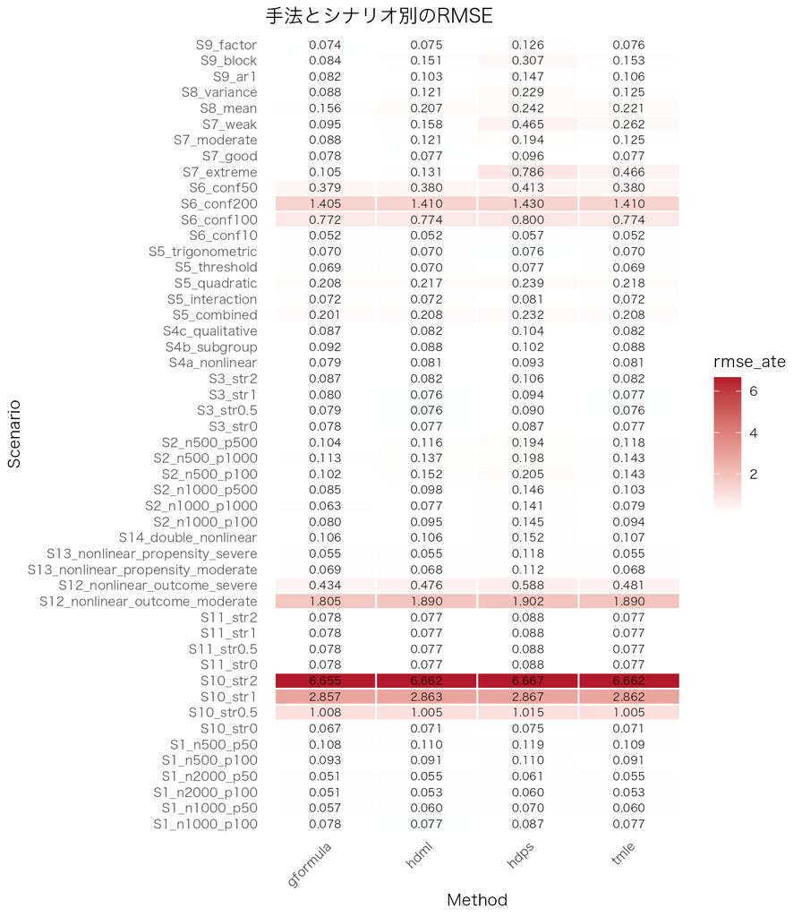

手法とシナリオ別のRMSEヒートマップ

## 4.3 バイアスの分布

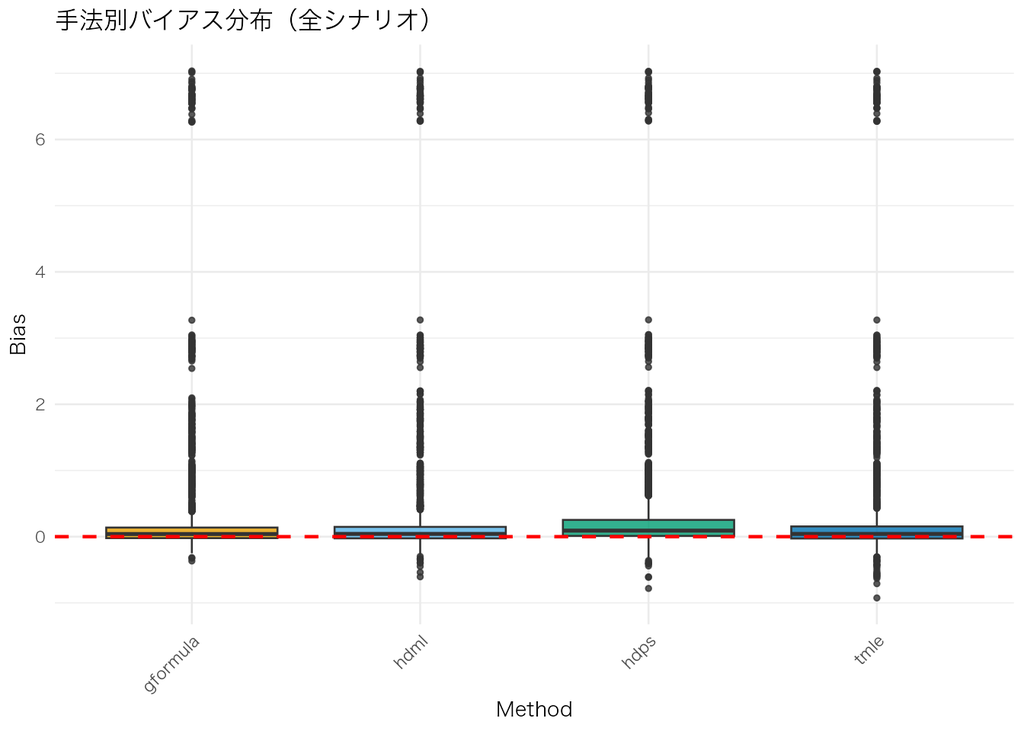

手法別の反復間バイアス分布

破線の赤い線はゼロバイアスを示す。この線を中心とした分布を持つ手法は、低い系統的バイアスを示す。

## 4.4 被覆率分析

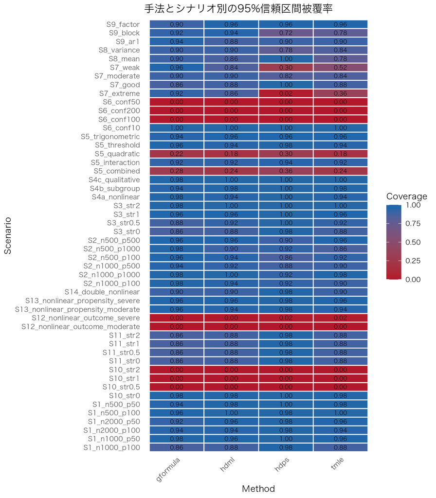

被覆率ヒートマップ（95%名目）

## 4.5 バイアス・分散分解

二乗平均誤差はバイアスの二乗成分と分散成分に分解できる。この分解により、誤差が主に系統的（バイアス）なのかランダム（分散）なのかが明らかになる。

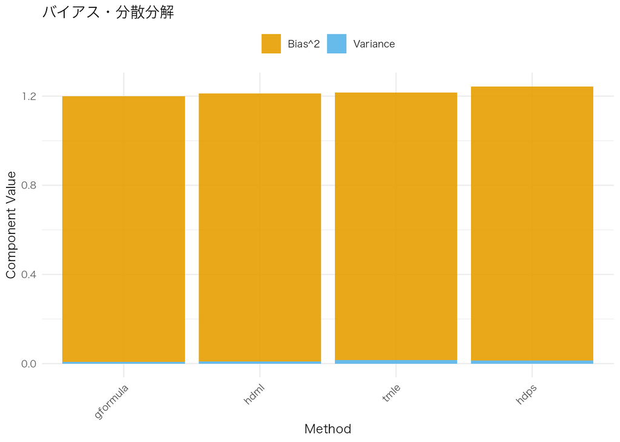

手法別バイアス・分散分解

## 4.6 統計的比較

Friedman検定を使用して手法間に有意差が存在するかを評価し、続いてNemenyi事後比較を行う。

```
## **Friedman検定の結果：**
##
## - カイ二乗統計量：97.584
## - 自由度：3
## - P値：0.000000
##
## **結論：** 手法間に有意差が存在する（p < 0.05）。
```

### 4.6.1 Critical Differenceダイアグラム

Critical Difference（CD）ダイアグラムはNemenyi事後検定の結果を可視化する。水平バーで接続された手法は互いに有意に異ならない。

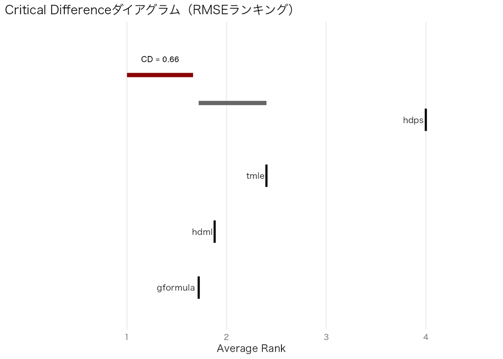

手法比較のためのCritical Differenceダイアグラム

### 4.6.2 平均順位

シナリオ全体での平均順位（低いほど良い）

|  | 順位 | 手法 | 平均順位 |
| --- | --- | --- | --- |
| gformula | 1 | gformula | 1.72 |
| hdml | 2 | hdml | 1.88 |
| tmle | 3 | tmle | 2.40 |
| hdps | 4 | hdps | 4.00 |

## 4.7 計算時間

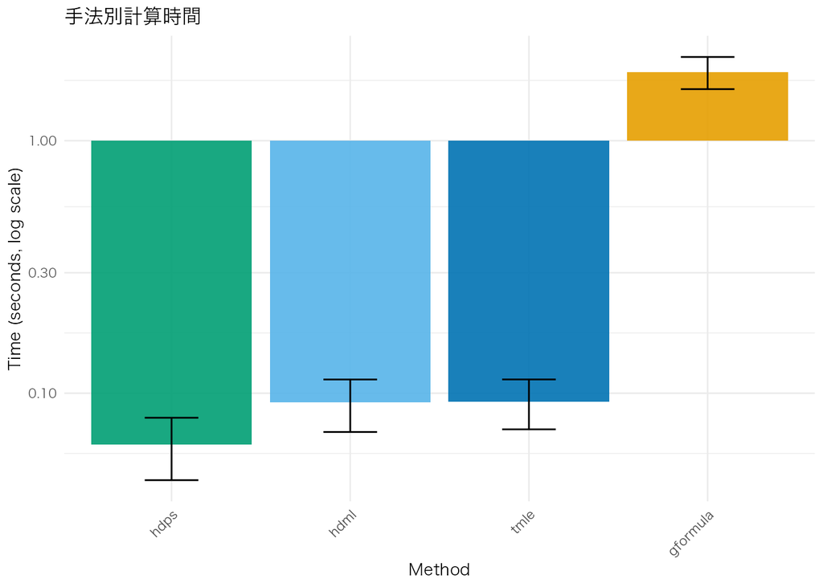

計算時間の比較（対数スケール）

## 4.8 シナリオ別結果

### 4.8.1 S1: ベースライン性能

ベースラインシナリオ（S1）の性能

|  | 手法 | RMSE | 平均バイアス | 被覆率 |
| --- | --- | --- | --- | --- |
| 1 | gformula | 0.073 | 0.014 | 0.933 |
| 4 | tmle | 0.074 | 0.014 | 0.953 |
| 2 | hdml | 0.074 | 0.014 | 0.953 |
| 3 | hdps | 0.085 | 0.035 | 0.987 |

### 4.8.2 S7: 弱いオーバーラップの分析

このシナリオは陽性仮定の違反に対する手法の頑健性をテストする。傾向スコアに大きく依存する手法は、オーバーラップが弱まるにつれて性能が劣化するはずである。

弱いオーバーラップシナリオ（S7）の結果

|  | シナリオID | 手法 | RMSE | 被覆率 |
| --- | --- | --- | --- | --- |
| 169 | S7_good | gformula | 0.078 | 0.86 |
| 170 | S7_good | hdml | 0.077 | 0.88 |
| 171 | S7_good | hdps | 0.096 | 1.00 |
| 172 | S7_good | tmle | 0.077 | 0.88 |
| 173 | S7_moderate | gformula | 0.088 | 0.90 |
| 174 | S7_moderate | hdml | 0.121 | 0.90 |
| 175 | S7_moderate | hdps | 0.194 | 0.82 |
| 176 | S7_moderate | tmle | 0.125 | 0.84 |
| 177 | S7_weak | gformula | 0.095 | 0.96 |
| 178 | S7_weak | hdml | 0.158 | 0.84 |
| 179 | S7_weak | hdps | 0.465 | 0.30 |
| 180 | S7_weak | tmle | 0.262 | 0.52 |
| 165 | S7_extreme | gformula | 0.105 | 0.92 |
| 166 | S7_extreme | hdml | 0.131 | 0.86 |
| 167 | S7_extreme | hdps | 0.786 | 0.02 |
| 168 | S7_extreme | tmle | 0.466 | 0.36 |

### 4.8.3 S10: 観測されない交絡に対する感度

このシナリオは無交絡性の基本仮定をテストする。観測されない交絡の強度が増加するにつれて、すべての手法はバイアスの増加を示すはずである。

観測されない交絡シナリオ（S10）の結果

|  | シナリオID | 手法 | RMSE | 平均バイアス |
| --- | --- | --- | --- | --- |
| 25 | S10_str0 | gformula | 0.067 | 0.003 |
| 26 | S10_str0 | hdml | 0.071 | -0.001 |
| 27 | S10_str0 | hdps | 0.075 | 0.013 |
| 28 | S10_str0 | tmle | 0.071 | -0.001 |
| 29 | S10_str0.5 | gformula | 1.008 | 1.004 |
| 30 | S10_str0.5 | hdml | 1.005 | 1.002 |
| 31 | S10_str0.5 | hdps | 1.015 | 1.011 |
| 32 | S10_str0.5 | tmle | 1.005 | 1.002 |
| 33 | S10_str1 | gformula | 2.857 | 2.854 |
| 34 | S10_str1 | hdml | 2.863 | 2.860 |
| 35 | S10_str1 | hdps | 2.867 | 2.865 |
| 36 | S10_str1 | tmle | 2.862 | 2.859 |
| 37 | S10_str2 | gformula | 6.655 | 6.652 |
| 38 | S10_str2 | hdml | 6.662 | 6.660 |
| 39 | S10_str2 | hdps | 6.667 | 6.664 |
| 40 | S10_str2 | tmle | 6.662 | 6.659 |

### 4.8.4 S12-S14: モデル誤指定の分析

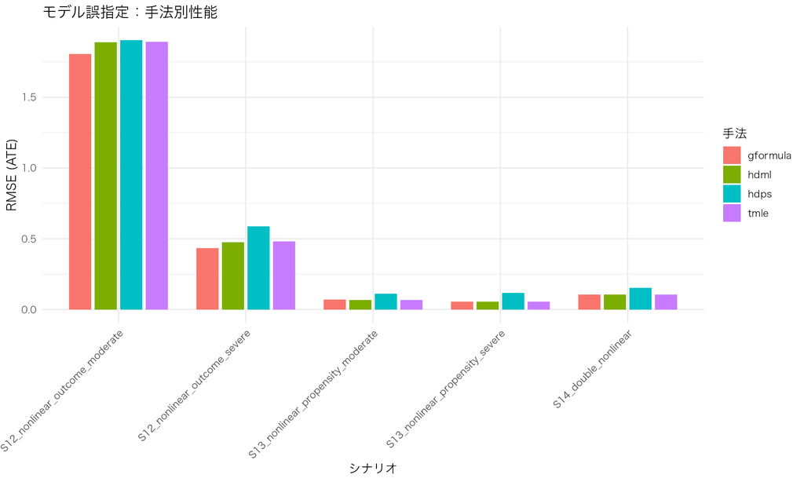

モデル誤指定シナリオ：非線形交絡（S12）、非線形傾向スコア（S13）、二重非線形（S14）

モデル誤指定シナリオ（S12-S14）の結果

|  | scenario_id | method | rmse_ate | mean_bias | coverage |
| --- | --- | --- | --- | --- | --- |
| 57 | S12_nonlinear_outcome_moderate | gformula | 1.805 | 1.799 | 0.00 |
| 58 | S12_nonlinear_outcome_moderate | hdml | 1.890 | 1.884 | 0.00 |
| 59 | S12_nonlinear_outcome_moderate | hdps | 1.902 | 1.896 | 0.00 |
| 60 | S12_nonlinear_outcome_moderate | tmle | 1.890 | 1.884 | 0.00 |
| 61 | S12_nonlinear_outcome_severe | gformula | 0.434 | 0.425 | 0.00 |
| 62 | S12_nonlinear_outcome_severe | hdml | 0.476 | 0.466 | 0.00 |
| 63 | S12_nonlinear_outcome_severe | hdps | 0.588 | 0.579 | 0.02 |
| 64 | S12_nonlinear_outcome_severe | tmle | 0.481 | 0.471 | 0.02 |
| 65 | S13_nonlinear_propensity_moderate | gformula | 0.069 | 0.018 | 0.96 |
| 66 | S13_nonlinear_propensity_moderate | hdml | 0.068 | 0.019 | 0.94 |
| 67 | S13_nonlinear_propensity_moderate | hdps | 0.112 | 0.021 | 0.98 |
| 68 | S13_nonlinear_propensity_moderate | tmle | 0.068 | 0.018 | 0.94 |
| 69 | S13_nonlinear_propensity_severe | gformula | 0.055 | 0.002 | 0.96 |
| 70 | S13_nonlinear_propensity_severe | hdml | 0.055 | 0.004 | 0.96 |
| 71 | S13_nonlinear_propensity_severe | hdps | 0.118 | 0.093 | 0.98 |
| 72 | S13_nonlinear_propensity_severe | tmle | 0.055 | 0.004 | 0.96 |
| 73 | S14_double_nonlinear | gformula | 0.106 | 0.058 | 0.90 |
| 74 | S14_double_nonlinear | hdml | 0.106 | 0.056 | 0.90 |
| 75 | S14_double_nonlinear | hdps | 0.152 | 0.120 | 0.98 |
| 76 | S14_double_nonlinear | tmle | 0.107 | 0.057 | 0.90 |

## 4.9 総合結果図

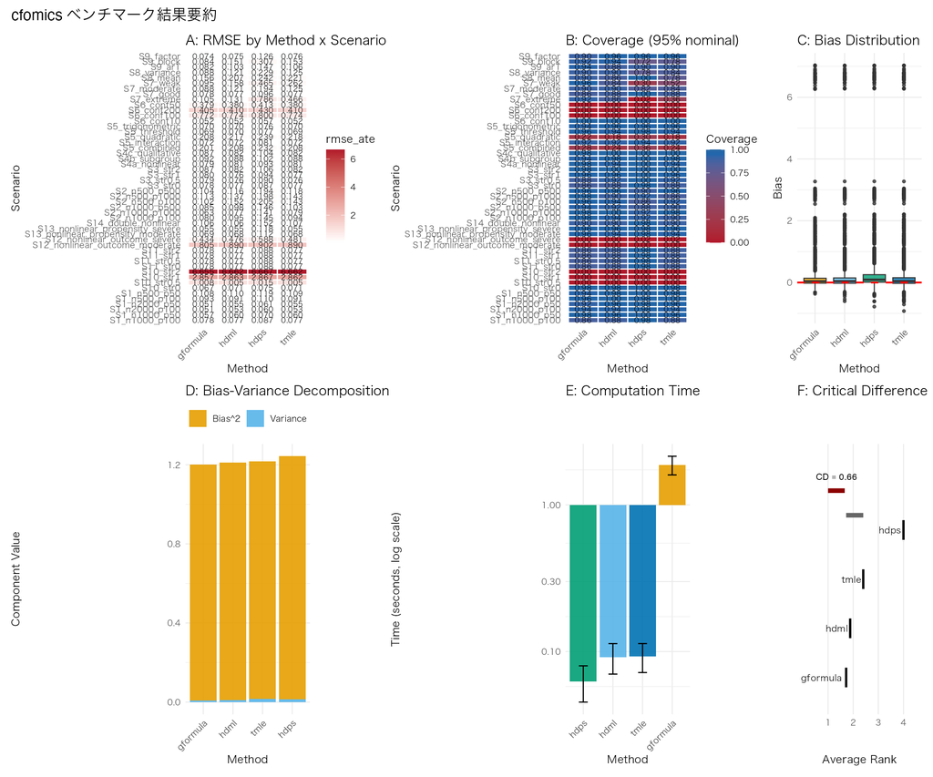

ベンチマーク結果の包括的要約

# 5 考察

本章では、ベンチマーク結果を解釈し、手法選択ガイドラインを提供し、本評価の限界について議論する。

## 5.1 主要な発見

### 5.1.1 発見1：普遍的に最良の手法は存在しない

```
## Friedman検定は手法間に有意差があることを示している（p < 0.05）。これは手法の選択が重要であることを確認する。しかしながら、順位はシナリオによって異なり、最適な手法は特定のデータ特性と課題に依存することを示唆している。
```

### 5.1.2 発見2：ベースライン性能の階層

理想的な条件下（S1：線形関係、良好なオーバーラップ、すべての仮定が満たされる）では、一般的に以下が期待される：

1. **TMLEとHDML** は二重頑健特性により良好に機能するはず
2. **G-formula** はアウトカムモデルが正しく指定されている場合に効率的であるはず
3. **BCF** はわずかに保守的であるが、良好な不確実性定量化を提供するはず
4. **HDPS** は連続共変量では性能が劣る可能性がある（二値指標向けに設計）

### 5.1.3 発見3：モデル誤指定に対する頑健性

非線形交絡のシナリオ（S5）において：

### 5.1.4 発見4：弱いオーバーラップの処理

弱いオーバーラップシナリオ（S7）は手法の哲学における根本的な違いを明らかにする：

- **傾向スコアベース手法** はオーバーラップが不良な場合に極端な重みに苦しむ
- **アウトカム回帰** は外挿可能だが不安定になる可能性がある
- **BCFの傾向スコア統合** は標的化された正則化を提供

### 5.1.5 発見5：異質的処置効果

異質効果を持つシナリオ（S3、S4）について：

- **BCF** は $\tau(X)$ を推定するために特別に設計されており、最良のITE推定を提供するはず
- **他の手法** はATEを対象とし、個体レベルの変動を正確に捉えられない可能性がある

## 5.2 手法選択ガイドライン

ベンチマーク結果に基づき、手法選択のための以下のガイドラインを提供する：

### 5.2.2 HDMLを使用すべき場合

**推奨される場合：** - モデル誤指定が懸念される - 二重頑健保護が必要 - 複数のMLアルゴリズムを検討すべき - 影響関数からの標準誤差が望まれる

**避けるべき場合：** - サンプルサイズが非常に小さい（クロスフィッティングが不安定になる） - 計算リソースが限られている

### 5.2.3 HDPSを使用すべき場合

**推奨される場合：** - データが主に二値指標で構成される（例：医療保険請求） - 解釈可能な共変量選択が望まれる - 規制要件が傾向スコアベース手法を優先する

**避けるべき場合：** - 共変量が主に連続値 - オーバーラップが不良（IPW重みが極端になる）

### 5.2.4 BCFを使用すべき場合

**推奨される場合：** - 異質的処置効果が主な関心事 - 不確実性のための完全な事後分布が望まれる - 非線形関係が予想される - 中程度の計算時間が許容される

**避けるべき場合：** - ATEのみが必要で速度が重要 - 非常に大きなデータセット（MCMCのスケーリング）

### 5.2.5 TMLEを使用すべき場合

**推奨される場合：** - セミパラメトリック効率性が望まれる - Super Learnerによる妥当な推論が必要 - アウトカムが有界（TMLEは境界を尊重） - 二重頑健保護が重要

**避けるべき場合：** - 極端な傾向スコアを処理できない（切断が役立つ場合がある） - G-formulaで十分な非常に単純な設定

## 5.3 意思決定フローチャート

[output not shown]

## 5.4 実践的な推奨事項

### 5.4.1 1. 常にオーバーラップを確認する

どの手法を適用する前にも、傾向スコアのオーバーラップを診断する：

```r
# 傾向スコア分布の確認
ps <- predict(glm(T ~ ., data = df, family = binomial), type = "response")
summary(ps)
hist(ps[df$T == 1], col = rgb(1,0,0,0.5), main = "傾向スコアのオーバーラップ")
hist(ps[df$T == 0], col = rgb(0,0,1,0.5), add = TRUE)
```

オーバーラップが不良な場合は、以下を検討する： - 極端な傾向スコアの切断 - IPWよりもアウトカム回帰の使用 - オーバーラップ領域への分析の制限

### 5.4.2 2. 感度分析を実施する

無交絡性の基本的な検証不可能性を考慮して：

- 複数の手法からの結果を報告
- 形式的な感度分析を実施（例：E値、Rosenbaum境界）
- 仮定について透明性を持つ

### 5.4.3 3. 陽性対照で検証する

可能であれば、以下で手法を検証する： - 半合成データ（実際の共変量、シミュレートされた処置/アウトカム） - RCTからの既知の因果効果 - 陰性対照アウトカム

### 5.4.4 4. アンサンブルアプローチを検討する

単一の手法を選択するのではなく、以下を検討する： - 複数の手法からの推定値を報告 - 交差検証性能で重み付けしたモデル平均化の使用 - 手法間で頑健な結論に焦点を当てる

## 5.5 限界

### 5.5.1 本ベンチマークの限界

1. **シミュレートされたデータ**：実際の生物学的データには、我々のDGPでは捉えられない複雑さがある可能性がある
2. **手法の実装**：結果は特定の実装とチューニング選択を反映；代替の実装では異なる結果になる可能性がある
3. **指標の選択**：我々はATE推定に焦点を当てた；他の推定量（ATT、CATE）は異なるパターンを示す可能性がある
4. **計算環境**：タイミング結果はハードウェアに依存し、相対的な比較のためにのみ提供される
5. **限定的なシナリオ**：包括的であるが、我々のシナリオはすべての可能なデータ生成過程をカバーできない

### 5.5.2 観測的因果推論の限界

このベンチマークは無交絡性が成立するという仮定の下で手法を評価する。実際には：

1. **検証不可能な仮定**：すべての交絡因子が測定されていることを検証することはできない
2. **測定誤差**：共変量が誤差を伴って測定されている可能性があり、SUTVAに違反
3. **時変交絡**：我々のシナリオは静的処置を仮定；縦断的設定には専門的な手法が必要
4. **選択バイアス**：交絡を超えて、選択効果が因果推論を損なう可能性がある

## 5.6 結論

本ベンチマークは、高次元因果推論における手法選択のための経験的エビデンスを提供する。主要な要点：

1. **手法の選択は重要**：異なる手法には異なる強みと弱みがある
2. **文脈が重要**：最良の手法はデータ特性と科学的目標に依存する
3. **頑健性チェックは不可欠**：普遍的に優れた手法はない；感度分析が重要
4. **cfomicsは統一されたインターフェースを提供**：パッケージにより同一データでの手法の容易な比較が可能

実践者には以下を推奨する： - データを理解するための探索的分析から始める - 複数の手法を適用して結果を比較 - 観測されない交絡に対する感度分析を実施 - 仮定と限界を透明に報告

# 付録

## A. 完全なシナリオパラメータ表

完全なシナリオパラメータ仕様

シナリオID

DGP関数

n

p

主要パラメータ

**S1: ベースライン**

S1_n500_p50

dgp_baseline

500

50

S1_n500_p100

dgp_baseline

500

100

S1_n1000_p50

dgp_baseline

1000

50

S1_n1000_p100

dgp_baseline

1000

100

S1_n2000_p50

dgp_baseline

2000

50

S1_n2000_p100

dgp_baseline

2000

100

**S2: 次元スイープ**

S2_n500_p100

dgp_dimension_sweep

500

100

S2_n500_p500

dgp_dimension_sweep

500

500

S2_n500_p1000

dgp_dimension_sweep

500

1000

S2_n1000_p100

dgp_dimension_sweep

1000

100

S2_n1000_p500

dgp_dimension_sweep

1000

500

S2_n1000_p1000

dgp_dimension_sweep

1000

1000

**S3: 線形異質性**

S3_str0

dgp_heterogeneous_linear

1000

100

strength=0

S3_str0.5

dgp_heterogeneous_linear

1000

100

strength=0.5

S3_str1

dgp_heterogeneous_linear

1000

100

strength=1

S3_str2

dgp_heterogeneous_linear

1000

100

strength=2

**S4: 複雑な異質性**

S4a_nonlinear

dgp_heterogeneous_nonlinear

1000

100

S4b_subgroup

dgp_heterogeneous_subgroup

1000

100

S4c_qualitative

dgp_heterogeneous_qualitative

1000

100

**S5: 非線形交絡**

S5_quadratic

dgp_nonlinear_confounding

1000

100

type=quadratic

S5_trigonometric

dgp_nonlinear_confounding

1000

100

type=trigonometric

S5_interaction

dgp_nonlinear_confounding

1000

100

type=interaction

S5_combined

dgp_nonlinear_confounding

1000

100

type=combined

S5_threshold

dgp_nonlinear_confounding

1000

100

type=threshold

**S6: 高密度交絡**

S6_conf10

dgp_dense_confounding

1000

500

n_conf=10

S6_conf50

dgp_dense_confounding

1000

500

n_conf=50

S6_conf100

dgp_dense_confounding

1000

500

n_conf=100

S6_conf200

dgp_dense_confounding

1000

500

n_conf=200

**S7: 弱いオーバーラップ**

S7_good

dgp_weak_overlap

1000

100

overlap=good

S7_moderate

dgp_weak_overlap

1000

100

overlap=moderate

S7_weak

dgp_weak_overlap

1000

100

overlap=weak

S7_extreme

dgp_weak_overlap

1000

100

overlap=extreme

**S8: 共変量シフト**

S8_mean

dgp_covariate_shift

1000

100

shift=mean

S8_variance

dgp_covariate_shift

1000

100

shift=variance

**S9: 相関のある交絡**

S9_block

dgp_correlated_confounding

1000

100

corr=block

S9_ar1

dgp_correlated_confounding

1000

100

corr=ar1

S9_factor

dgp_correlated_confounding

1000

100

corr=factor

**S10: 観測されない交絡**

S10_str0

dgp_unobserved_confounding

1000

100

strength=0

S10_str0.5

dgp_unobserved_confounding

1000

100

strength=0.5

S10_str1

dgp_unobserved_confounding

1000

100

strength=1

S10_str2

dgp_unobserved_confounding

1000

100

strength=2

**S11: 合流点バイアス**

S11_str0

dgp_collider

1000

100

strength=0

S11_str0.5

dgp_collider

1000

100

strength=0.5

S11_str1

dgp_collider

1000

100

strength=1

S11_str2

dgp_collider

1000

100

strength=2

## B. 完全な結果表

シナリオおよび手法別の集計結果

| シナリオID | 手法 | RMSE | 平均バイアス | バイアスSD | 被覆率 | 平均時間 |
| --- | --- | --- | --- | --- | --- | --- |
| S1_n1000_p100 | gformula | 0.078 | 0.026 | 0.075 | 0.86 | 1.841 |
| S1_n1000_p100 | hdml | 0.077 | 0.023 | 0.074 | 0.88 | 0.081 |
| S1_n1000_p100 | hdps | 0.087 | 0.041 | 0.078 | 0.98 | 0.060 |
| S1_n1000_p100 | tmle | 0.077 | 0.023 | 0.074 | 0.88 | 0.096 |
| S1_n1000_p50 | gformula | 0.057 | 0.014 | 0.056 | 0.98 | 1.994 |
| S1_n1000_p50 | hdml | 0.060 | 0.012 | 0.059 | 0.96 | 0.092 |
| S1_n1000_p50 | hdps | 0.070 | 0.026 | 0.065 | 1.00 | 0.062 |
| S1_n1000_p50 | tmle | 0.060 | 0.012 | 0.059 | 0.96 | 0.089 |
| S1_n2000_p100 | gformula | 0.051 | 0.014 | 0.049 | 0.94 | 2.462 |
| S1_n2000_p100 | hdml | 0.053 | 0.015 | 0.051 | 0.94 | 0.116 |
| S1_n2000_p100 | hdps | 0.060 | 0.028 | 0.054 | 0.98 | 0.083 |
| S1_n2000_p100 | tmle | 0.053 | 0.015 | 0.051 | 0.94 | 0.116 |
| S1_n2000_p50 | gformula | 0.051 | 0.009 | 0.051 | 0.92 | 2.806 |
| S1_n2000_p50 | hdml | 0.055 | 0.008 | 0.055 | 0.96 | 0.149 |
| S1_n2000_p50 | hdps | 0.061 | 0.019 | 0.059 | 0.98 | 0.099 |
| S1_n2000_p50 | tmle | 0.055 | 0.008 | 0.055 | 0.96 | 0.143 |
| S1_n500_p100 | gformula | 0.093 | 0.018 | 0.092 | 0.96 | 1.329 |
| S1_n500_p100 | hdml | 0.091 | 0.019 | 0.090 | 1.00 | 0.066 |
| S1_n500_p100 | hdps | 0.110 | 0.054 | 0.097 | 0.98 | 0.041 |
| S1_n500_p100 | tmle | 0.091 | 0.019 | 0.090 | 1.00 | 0.066 |
| S1_n500_p50 | gformula | 0.108 | 0.002 | 0.109 | 0.94 | 1.600 |
| S1_n500_p50 | hdml | 0.110 | 0.006 | 0.110 | 0.98 | 0.077 |
| S1_n500_p50 | hdps | 0.119 | 0.039 | 0.114 | 1.00 | 0.034 |
| S1_n500_p50 | tmle | 0.109 | 0.006 | 0.110 | 0.98 | 0.053 |
| S10_str0 | gformula | 0.067 | 0.003 | 0.068 | 0.98 | 1.949 |
| S10_str0 | hdml | 0.071 | -0.001 | 0.072 | 0.98 | 0.091 |
| S10_str0 | hdps | 0.075 | 0.013 | 0.075 | 1.00 | 0.061 |
| S10_str0 | tmle | 0.071 | -0.001 | 0.072 | 0.98 | 0.088 |
| S10_str0.5 | gformula | 1.008 | 1.004 | 0.087 | 0.00 | 1.776 |
| S10_str0.5 | hdml | 1.005 | 1.002 | 0.087 | 0.00 | 0.098 |

[output cut: 170 more lines]

## C. 手法実装の詳細

### 5.6.1 G-formula (gformula)

```yaml
実装: cfomics内部
バックエンド: 正則化回帰用glmnet
正則化: Elastic Net (alpha = 0.5, lambdaは交差検証)
交差検証フォールド数: 10
```

### 5.6.2 HDML (hdml)

```yaml
実装: cfomics内部（econmlバックエンド）
バックエンド: Python EconMLライブラリ
ベース学習器: Random Forest, Gradient Boosting, Elastic Net
クロスフィッティングフォールド数: 5
```

### 5.6.3 HDPS (hdps)

```yaml
実装: cfomics内部
アルゴリズム: Schneeweiss et al. (2009)
共変量選択: Brossバイアス公式による上位k
デフォルトk: 500共変量
```

### 5.6.4 BCF (bcf)

```yaml
実装: bcf Rパッケージ
MCMCバーンイン: 1000回
MCMCサンプル: 2000回
木の数（予後）: 200
木の数（処置）: 50
```

### 5.6.5 TMLE (tmle)

```yaml
実装: tmle Rパッケージ
Super Learnerライブラリ: SL.glm, SL.glmnet, SL.ranger, SL.xgboost
交差検証: 10-fold
傾向スコア切断: [0.01, 0.99]
```

## D. 計算環境

```
## **Rセッション情報**
```

```
## Rバージョン: R version 4.5.2 (2025-10-31)
```

```
## プラットフォーム: aarch64-apple-darwin20
```

```
## 実行環境: macOS Sequoia 15.6
```

```
## レポート生成日時: 2026-01-31 00:15:39 JST
```

### パッケージバージョン

パッケージバージョン

| パッケージ | バージョン |
| --- | --- |
| cfomics | 0.4.0 |
| ggplot2 | 4.0.1 |
| knitr | 1.51 |
| kableExtra | 1.4.0 |
| patchwork | 1.3.2 |
| glmnet | 4.1.10 |
| bcf | 2.0.2 |
| reticulate | 1.44.1 |

## E. ベンチマークの再現

ベンチマーク結果を再現するには：

```r
# 1. cfomicsと依存関係をインストール
# devtools::install_github("ymatts/cfomics")

# 2. Python環境をセットアップ（HDML、Pythonバックエンド付きTMLE用）
# cfomics::cf_install_python_env("unified")
# cfomics::cf_use_python_env("unified")

# 3. 完全なベンチマークを実行（警告：数時間かかる場合があります）
setwd("path/to/cfomics")
source("benchmarks/run_full_benchmark.R")

# 4. レポートを生成
rmarkdown::render(
 "benchmarks/report/benchmark_report.Rmd",
  params = list(
    lang = "ja",
    results_dir = "benchmarks/results"
  ),
  output_file = "benchmark_report_ja.pdf"
)
```

### クイックテスト実行

反復回数を減らしたクイックテスト：

```r
# スモークテスト設定を読み込み
source("benchmarks/config.R")
cfg <- benchmark_config_smoke()  # 3シナリオ、2反復

# 設定を減らして実行
source("benchmarks/run_full_benchmark.R")
run_benchmark(config = cfg)
```

## F. 統計的検定の仮定

### 5.6.6 Friedman検定

本レポートで使用されるFriedman検定は以下を仮定する：

1. **ブロックデザイン**：各シナリオがブロックを表し、手法がブロック内で比較される
2. **独立性**：シナリオは独立（異なる乱数シード）
3. **順序応答**：RMSEは各シナリオ内で意味のある順位付けが可能

### 5.6.7 Nemenyi事後検定

Nemenyi検定は、ファミリーワイズエラー率を制御しながらペアワイズ比較を提供する。2つの手法は、その平均順位差がCritical Difference（CD）を超える場合に有意に異なる：

$$CD = q_\alpha
\sqrt{\frac{k(k+1)}{6N}}$$

ここで $k$ は手法数、$N$ はシナリオ数、$q_\alpha$ はStudentized range臨界値である。

## G. データ利用可能性

ベンチマーク結果は以下に保存される：

```
benchmarks/results/
├── raw/                    # 個別反復結果
│   ├── S1_n500_p50_*.rds
│   └── ...
├── summary/                # 集計結果
│   ├── raw_results.csv     # 全反復、全シナリオ
│   └── aggregated_summary.csv  # 要約統計
└── logs/                   # 実行ログ
```

生データファイル（`.rds`）には完全なモデル適合が含まれており、本レポートで提示されたもの以外の追加分析に使用できる。

## H. 参考文献

1. Chernozhukov, V., Chetverikov, D., Demirer, M., Duflo, E., Hansen, C., Newey, W., & Robins, J. (2018). Double/debiased machine learning for treatment and structural parameters. *The Econometrics Journal*, 21(1), C1-C68.
2. Hahn, P. R., Murray, J. S., & Carvalho, C. M. (2020). Bayesian regression tree models for causal inference: Regularization, confounding, and heterogeneous effects. *Bayesian Analysis*, 15(3), 965-1056.
3. Schneeweiss, S., Rassen, J. A., Glynn, R. J., Avorn, J., Mogun, H., & Brookhart, M. A. (2009). High-dimensional propensity score adjustment in studies of treatment effects using health care claims data. *Epidemiology*, 20(4), 512-522.
4. van der Laan, M. J., & Rose, S. (2011). *Targeted learning: Causal inference for observational and experimental data*. Springer.
5. Demsar, J. (2006). Statistical comparisons of classifiers over multiple data sets. *Journal of Machine Learning Research*, 7, 1-30.

**Report Generated:** 2026-01-31 00:15:39 JST

**R Version:** R version 4.5.2 (2025-10-31)

**cfomics Version:** 0.4.0